# A Tufte Handout for Probability and Data Homework

An implementation in R Markdown

Robert W. Walker

2025-10-23

# Data Examples

## Disability Expenditures

**ID** is the unique identification code for each consumer. It is similar to a social security number and used for identification purposes.

**Age cohort/age** is a key variable in the case exercise. While age is a legal basis for discrimination in many situations, age is not an attribute that would be considered in a discrimination claim for this particular population. The purpose of providing funds to those with developmental disabilities is to help them live like those without disabilities. As consumers get older, their financial needs increase as they move out of their parent’s home, etc. Therefore, it is expected that expenditures for older consumers will be higher than for the younger consumers.

We have included both binned (**Age cohort**) and unbinned (**Age**) variables to represent a consumer’s age. The binned age variable is represented in the data set as six age cohorts. Each consumer is assigned to an age cohort based on their years since birth. The six cohorts include: 0-5 years old, 6-12, 13-17, 18-21, 22-50, and 51+. The cohorts are established based on the amount of financial support typically required during a particular life phase.

The 0-5 cohort (preschool age) has the fewest needs and requires the least amount of funding. For the 6-12 cohort (elementary school age) and 13-17 (high school age), a number of needed services are provided by schools. The 18-21 cohort is typically in a transition phase as the consumers begin moving out from their parents’ homes into community centers or living on their own. The majority of those in the 22-50 cohort no longer live with their parents but may still receive some support from their family. Those in the 51+ cohort have the most needs and require the most amount of funding because they are living on their own or in community centers and often have no living parents.

**Gender** is included in the data set as another variable to consider because it is an attribute on which many discrimination cases are based.

**Expenditures** variable represents the annual expenditures the State spends on each consumer in supporting these individuals and their families. It is important that students realize this is the amount each consumer receives from the State. Expenditures include services such as: respite for their families, psychological services, medical expenses, transportation, and costs related to housing such as rent (especially for adult consumers living outside their parent’s home).

**Ethnicity** is the key demographic variable in the data set as it pertains to the case. Eight ethnic groups are represented in the data set. These groups reflect the demographic profile of the State of California. Our key area of interest will become Hispanic and White, non-Hispanic comparisons.

# Questions for Discrimination

## Averages

Average Expenditures

1. What is the average of expenditures for: (a) all males vs. all females,

The average for females is 18,129.61 dollars and the average for males is 18001.2 dollars.

[interactive table not shown]

2. all Hispanics and all White, non-Hispanics,

The average expenditure for Hispanic clients is 11,065.57 dollars. The average expenditure for White not Hispanic clients is 24,697.55 dollars.

[interactive table not shown]

3. all 22-50 year olds,

   The average expenditure for 22 to 50 year old clients is 40,209.28 dollars.

[interactive table not shown]

4. all male, White non-Hispanics,

   The average expenditure for male and White not Hispanic clients is 24,573.80 dollars.

[interactive table not shown]

5. all Asian, 22-50 year olds?

   The average expenditure for Asian 22 to 50 year old clients is 39,580.52 dollars.

[interactive table not shown]

## Medians

Median Expenditures

2. What is the median of expenditures for:
1. all males vs. all females,

[interactive table not shown]

2. all Hispanics and all White, non-Hispanics,

   The median expenditure for Hispanic clients is 3,952 dollars and the median expenditure for White not Hispanic clients is 15,718 dollars. This difference is large.

[interactive table not shown]

3. all 13-17 year olds,

   The median expenditure for 13 to 17 year old clients is 3,952 dollars. Note the similarity with the above.

[interactive table not shown]

4. all male, White non-Hispanics,

   The median expenditure for White not Hispanic male clients is 27,390.50 dollars.

[interactive table not shown]

5. all Asian, 13-17 year olds?

   The median expenditure for 13 to 17 year old Asian clients is 3,628.50 dollars.

[interactive table not shown]

## Elements of the Interquartile Range

The middle 50% of expenditures

3. What is the range of the middle 50% of expenditures for: (a) all males vs. all females,

   The middle fifty percent of expenditures for female clients ranges from 2872.50 to 39,487.50 dollars and for male clients ranges from 2,954 to 37,201 dollars. This range, for males, is entirely contained in the range for females.

[interactive table not shown]

2. all Hispanics and all White, non-Hispanics,

   The middle fifty percent of expenditures for Hispanic clients ranges from 2331.25 to 10,292.50 dollars and for White not Hispanic clients ranges from 3,977 to 43,134 dollars.

[interactive table not shown]

3. all 13-17 year olds,

   The middle fifty percent of expenditures for 13 to 17 year old clients ranges from 3,306.50 to 4,665.50 dollars. Expenditures seem to balloon for adults; we can roughly compare this range to that in subpart (e).

[interactive table not shown]

4. all male, White non-Hispanics, and

   The middle fifty percent of expenditures for male and White not Hispanic clients ranges from 4195.25 to 40,817.50 dollars.

[interactive table not shown]

5. all Asian, 18-21 year olds?

   The middle fifty percent of expenditures for clients 18 to 21 years of age and Asian ranges from 7683 to 11,282 dollars.

[interactive table not shown]

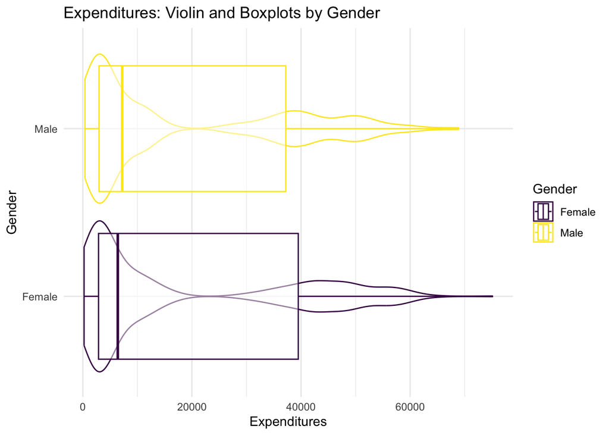

## Summary Thoughts and Interpretation

4. Does discrimination in expenditures exist? There are two relevant potential forms of actionable discrimination: gender and ethnicity. Evaluate these two questions with the appropriate pivot table equivalent defined for each.

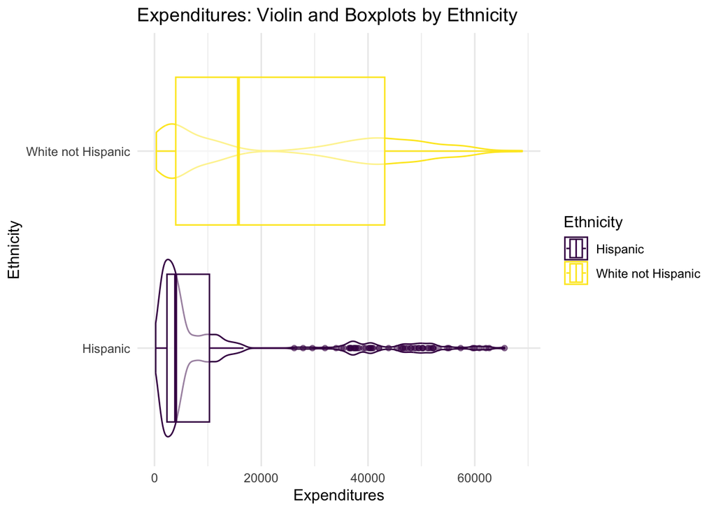

**Not in gender, perhaps in ethnicity, where there is wide disparity.**.

5. It is claimed that there are important disparities between Hispanic and White, not Hispanic. Is this true? Filter only Hispanics and White, not Hispanic. 6. After filtering only Hispanics and White, not Hispanic, compare the two groups by Age Cohort. What seems to be going on?

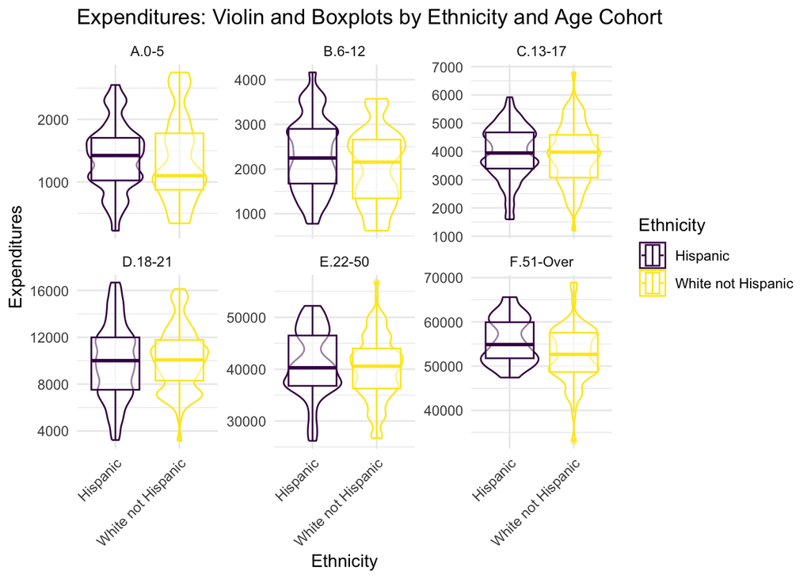

> The apparent disparities seem to be accounted for by a different underlying age distribution among the two groups as the within age group comparisons show no obvious differences.

[interactive table not shown]

Consider the following additional issues keeping in mind that the data are a random sample from a broader population. (1) What is the relationship between age cohort and ethnicity for the comparison of White and Hispanic? (2) Are expenditures different by age cohorts? (3) How do the previous two answers interact to influence claims of discrimination?

> In the right column above, there are far more Hispanic than White not Hispanic clients in the age cohorts under the age of 21, but in the older cohorts, this trend reverses and the vast majority of clients are White not Hispanic. When we note that expenditures are related to age, the apparent discrepancy in expenditures is to be expected to result from this distribution of ages among clients of varying ethnicities.

# Berkeley Discrimination

Is there evidence of sex bias in admission practices? Data on admissions to the University of California at Berkeley graduate programs in six departments are presented for the population of applicants. Admit measures whether or not the applicant was admitted; M.F measures the gender of the applicant; Dept measures the department in a classification ranging from A to F.

- Provide a table of M.F and Admit.

```
## Cross-tabs
## Data     : UCBAdmit
## Variables: M.F, Admit
## Null hyp.: there is no association between M.F and Admit
## Alt. hyp.: there is an association between M.F and Admit
##
## Observed:
##         Admit
## M.F      No    Yes   Total
##   Female 1,278   557 1,835
##   Male   1,493 1,198 2,691
##   Total  2,771 1,755 4,526
##
## Row percentages:
##         Admit
## M.F        No  Yes Total
##   Female 0.70 0.30     1
##   Male   0.55 0.45     1
##   Total  0.61 0.39     1
##
## Chi-squared: 92.205 df(1), p.value < .001
##
## 0.0 % of cells have expected values below 5
```

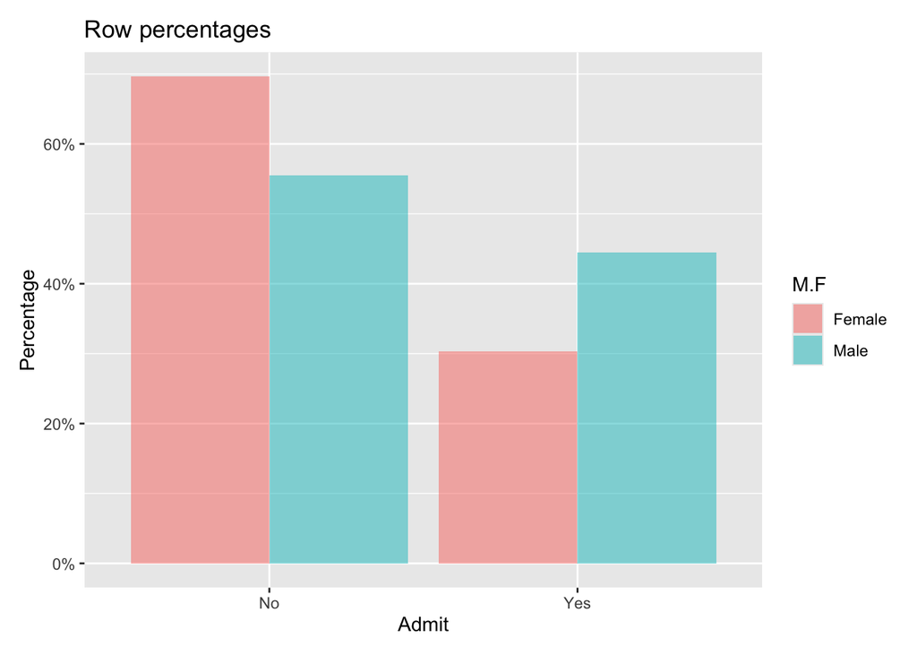

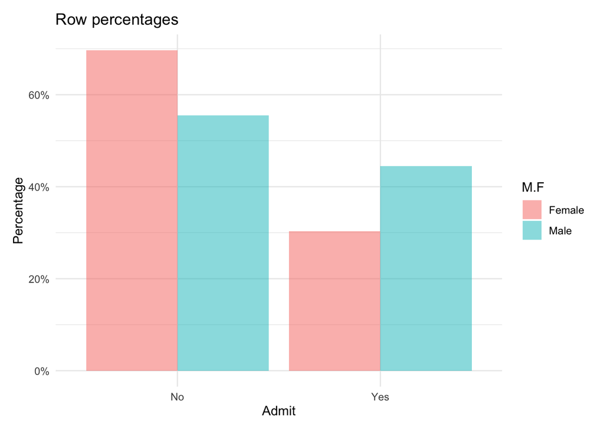

## Conditional Probability

- Provide the two relevant tables of conditional probabilities for that table.

```
## Cross-tabs
## Data     : UCBAdmit
## Variables: M.F, Admit
## Null hyp.: there is no association between M.F and Admit
## Alt. hyp.: there is an association between M.F and Admit
##
## Observed:
##         Admit
## M.F      No    Yes   Total
##   Female 1,278   557 1,835
##   Male   1,493 1,198 2,691
##   Total  2,771 1,755 4,526
##
## Row percentages:
##         Admit
## M.F        No  Yes Total
##   Female 0.70 0.30     1
##   Male   0.55 0.45     1
##   Total  0.61 0.39     1
##
## Column percentages:
##         Admit
## M.F        No  Yes Total
##   Female 0.46 0.32  0.41
##   Male   0.54 0.68  0.59
##   Total  1.00 1.00  1.00
##
## Chi-squared: 92.205 df(1), p.value < .001
##
## 0.0 % of cells have expected values below 5
```

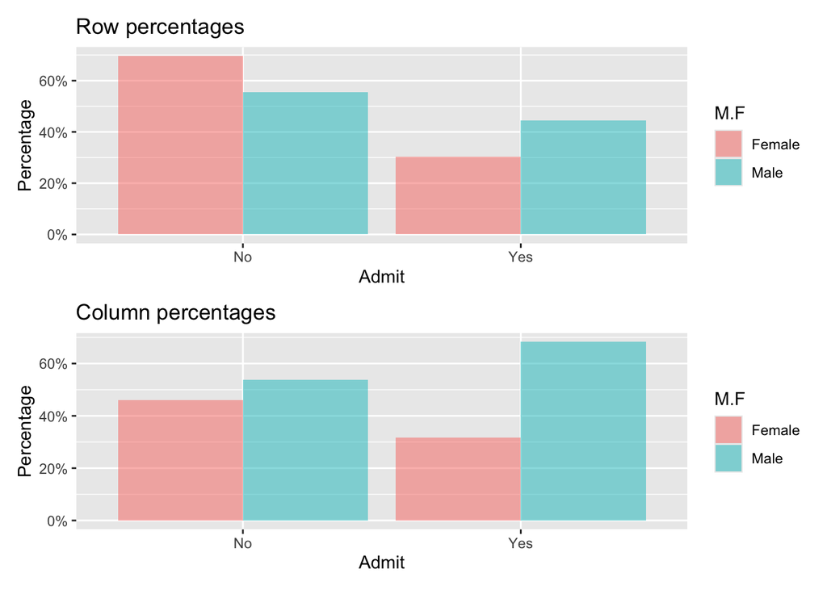

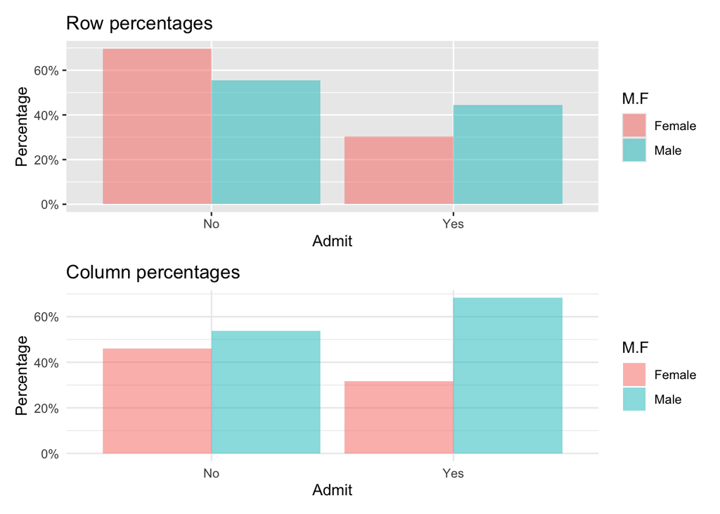

## Some questions….

Some questions….

1. Are men and women admitted to graduate programs at the same rate?

> No. Women have a 0.3 probability of admission while men have a 0.45 probability of admission.
2. Display and tabulate applications by department.

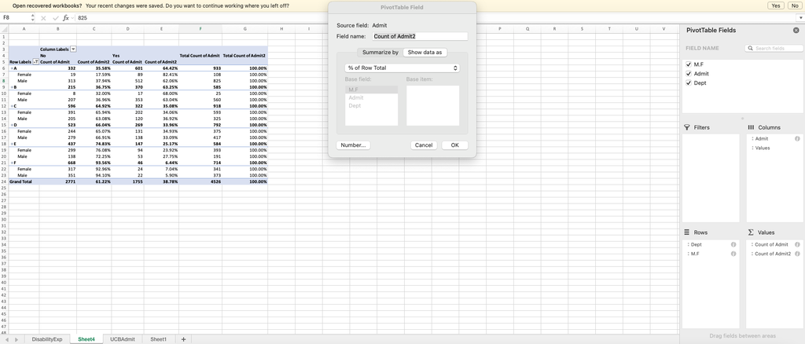

Screenshot

## Results

### Department A

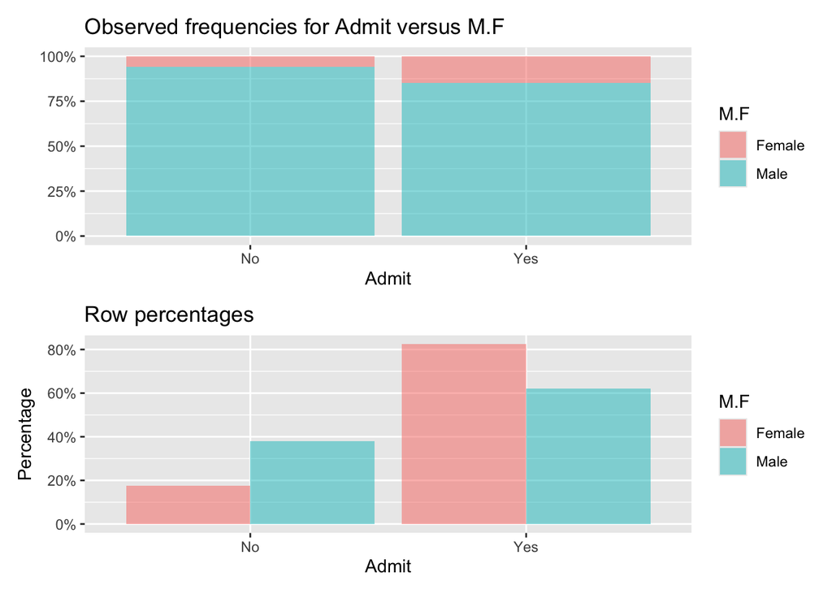

```
## Cross-tabs
## Data     : UCBAdmit
## Filter   : Dept=='A'
## Variables: M.F, Admit
## Null hyp.: there is no association between M.F and Admit
## Alt. hyp.: there is an association between M.F and Admit
##
## Observed:
##         Admit
## M.F      No  Yes Total
##   Female  19  89 108
##   Male   313 512 825
##   Total  332 601 933
##
## Row percentages:
##         Admit
## M.F        No  Yes Total
##   Female 0.18 0.82     1
##   Male   0.38 0.62     1
##   Total  0.36 0.64     1
##
## Chi-squared: 17.248 df(1), p.value < .001
##
## 0.0 % of cells have expected values below 5
```

### Department B

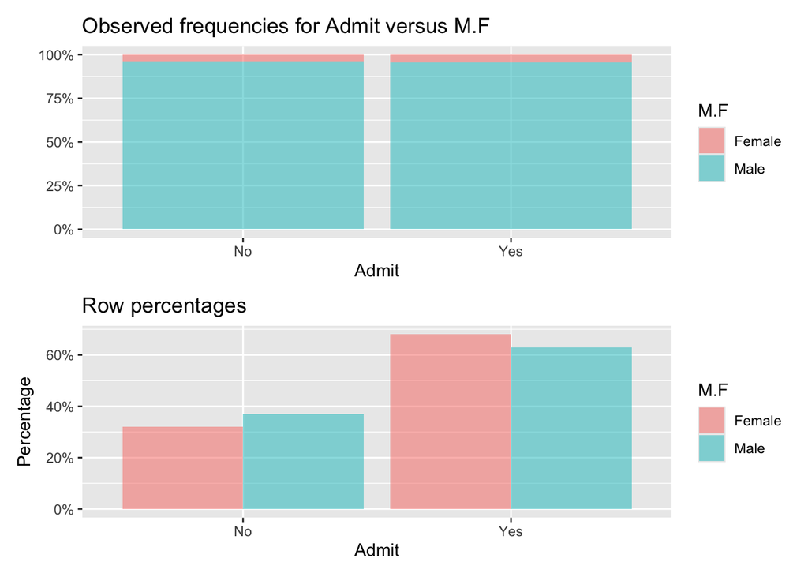

```
## Cross-tabs
## Data     : UCBAdmit
## Filter   : Dept=='B'
## Variables: M.F, Admit
## Null hyp.: there is no association between M.F and Admit
## Alt. hyp.: there is an association between M.F and Admit
##
## Observed:
##         Admit
## M.F      No  Yes Total
##   Female   8  17  25
##   Male   207 353 560
##   Total  215 370 585
##
## Row percentages:
##         Admit
## M.F        No  Yes Total
##   Female 0.32 0.68     1
##   Male   0.37 0.63     1
##   Total  0.37 0.63     1
##
## Chi-squared: 0.254 df(1), p.value 0.614
##
## 0.0 % of cells have expected values below 5
```

### Department C

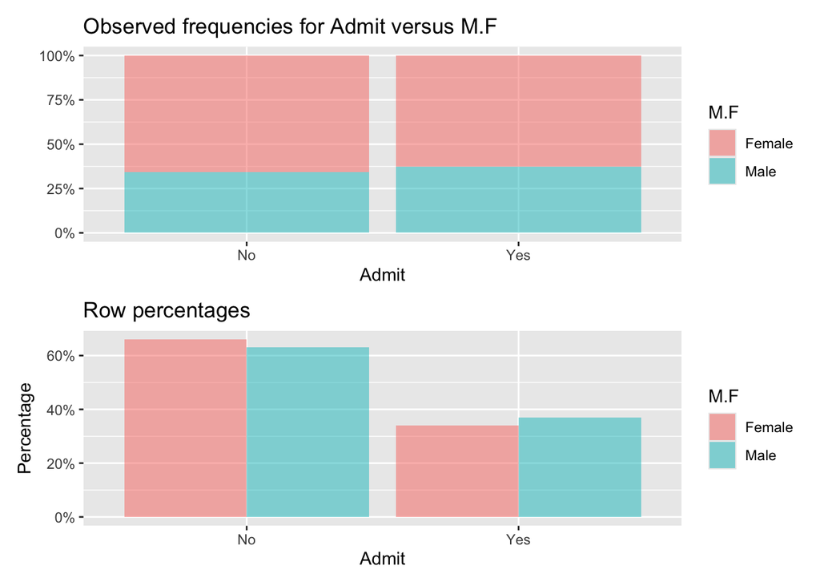

```
## Cross-tabs
## Data     : UCBAdmit
## Filter   : Dept=='C'
## Variables: M.F, Admit
## Null hyp.: there is no association between M.F and Admit
## Alt. hyp.: there is an association between M.F and Admit
##
## Observed:
##         Admit
## M.F      No  Yes Total
##   Female 391 202 593
##   Male   205 120 325
##   Total  596 322 918
##
## Row percentages:
##         Admit
## M.F        No  Yes Total
##   Female 0.66 0.34     1
##   Male   0.63 0.37     1
##   Total  0.65 0.35     1
##
## Chi-squared: 0.754 df(1), p.value 0.385
##
## 0.0 % of cells have expected values below 5
```

### Department D

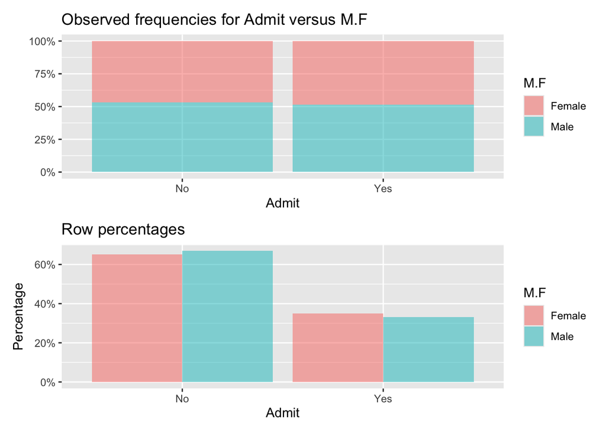

```
## Cross-tabs
## Data     : UCBAdmit
## Filter   : Dept=='D'
## Variables: M.F, Admit
## Null hyp.: there is no association between M.F and Admit
## Alt. hyp.: there is an association between M.F and Admit
##
## Observed:
##         Admit
## M.F      No  Yes Total
##   Female 244 131 375
##   Male   279 138 417
##   Total  523 269 792
##
## Row percentages:
##         Admit
## M.F        No  Yes Total
##   Female 0.65 0.35     1
##   Male   0.67 0.33     1
##   Total  0.66 0.34     1
##
## Chi-squared: 0.298 df(1), p.value 0.585
##
## 0.0 % of cells have expected values below 5
```

### Department E

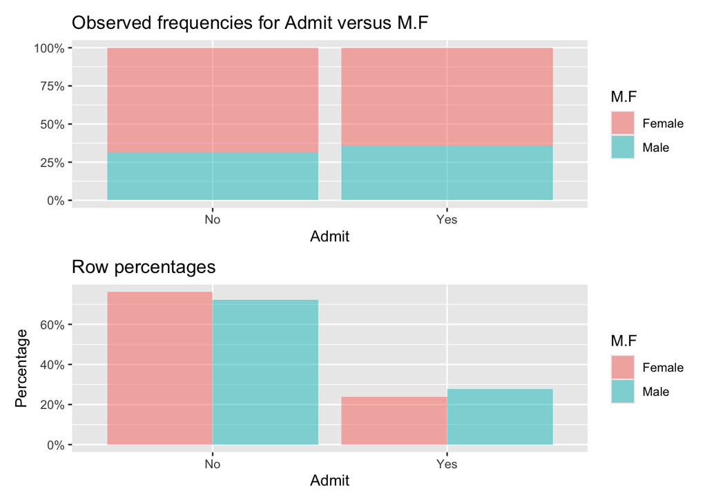

```
## Cross-tabs
## Data     : UCBAdmit
## Filter   : Dept=='E'
## Variables: M.F, Admit
## Null hyp.: there is no association between M.F and Admit
## Alt. hyp.: there is an association between M.F and Admit
##
## Observed:
##         Admit
## M.F      No  Yes Total
##   Female 299  94 393
##   Male   138  53 191
##   Total  437 147 584
##
## Row percentages:
##         Admit
## M.F        No  Yes Total
##   Female 0.76 0.24     1
##   Male   0.72 0.28     1
##   Total  0.75 0.25     1
##
## Chi-squared: 1.001 df(1), p.value 0.317
##
## 0.0 % of cells have expected values below 5
```

### Department F

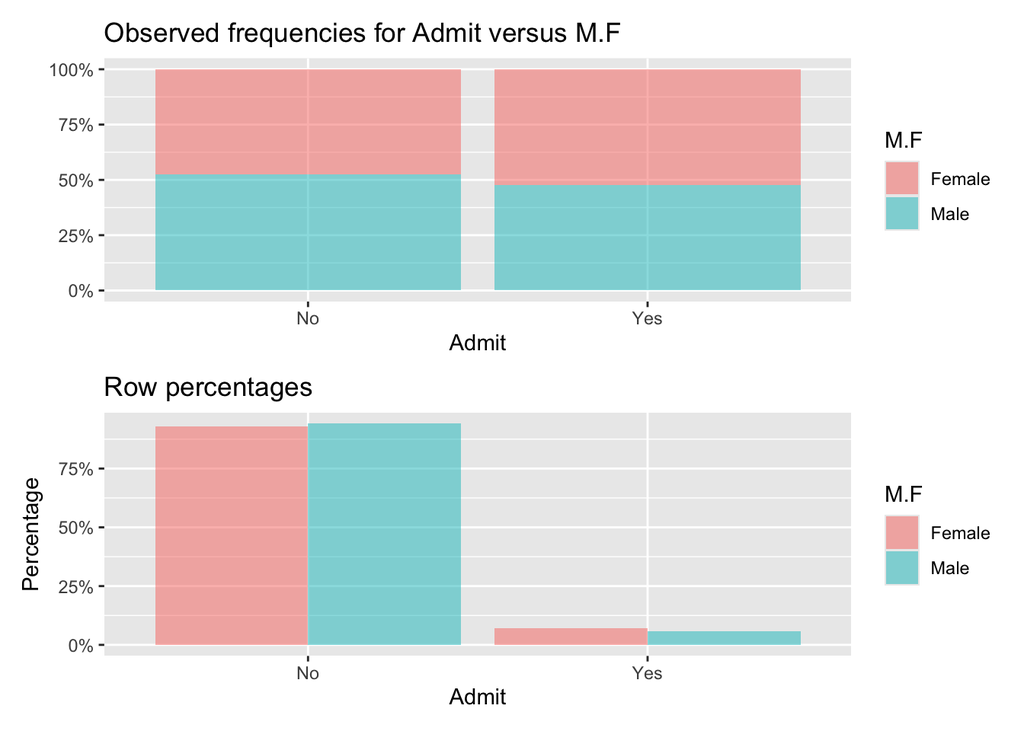

```
## Cross-tabs
## Data     : UCBAdmit
## Filter   : Dept=='F'
## Variables: M.F, Admit
## Null hyp.: there is no association between M.F and Admit
## Alt. hyp.: there is an association between M.F and Admit
##
## Observed:
##         Admit
## M.F      No  Yes Total
##   Female 317  24 341
##   Male   351  22 373
##   Total  668  46 714
##
## Row percentages:
##         Admit
## M.F        No  Yes Total
##   Female 0.93 0.07     1
##   Male   0.94 0.06     1
##   Total  0.94 0.06     1
##
## Chi-squared: 0.384 df(1), p.value 0.535
##
## 0.0 % of cells have expected values below 5
```

3. Do any departments show differences in admissions rates by gender?

4. Discuss 1 and 2 in light of claims of discrimination.

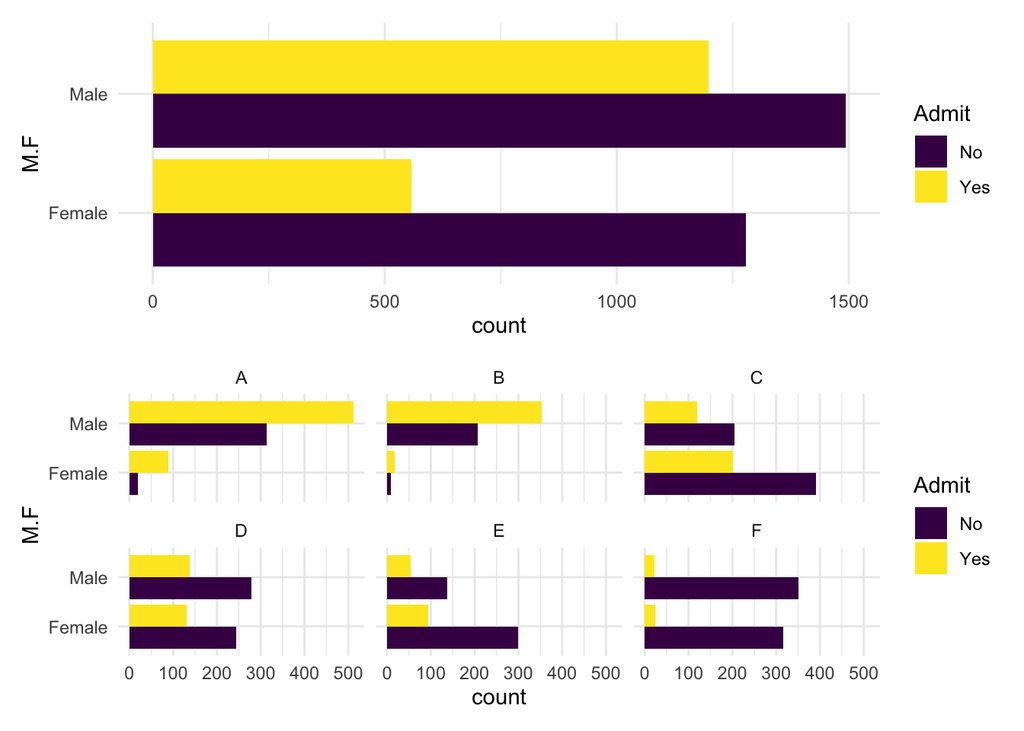

5. Provide a graphic that showcases the apparent disparities and a graphic that dispels them that combines all three dimensions of the table.

The top panel showcases the aggregate disparity: 45% vs. 30%.

The bottom panel shows that in almost all departments, women are admitted at a higher rate than men except in Deparments C and E and the differences in those departments are small.

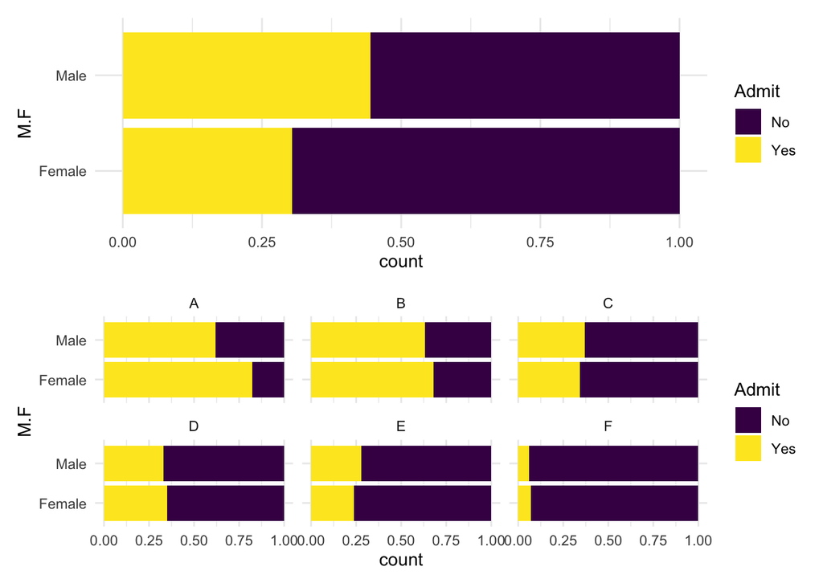